# préserver et ouvrir ses codes sources et logiciels

Printemps de la donnée 2024

Jozefina Sadowska

jozefina.sadowska@inria.fr

INRIA

Damien Belvèze

damien.belveze@univ-rennes.fr

Université de Rennes

Jun 13, 2024

[figure not shown]

[figure not shown]

[figure not shown]

[figure not shown]

If you ever find yourself in an award committee, or a grant funding panel, or a search committee, may you voice these thoughts out loud. **Software development contributions are immensely valuable**.

Software developed by PhD students and postdocs without any formal training **has gone on to save academia many millions on software licenses**, in addition to **enabling research that was not possible otherwise**.

I wish this had been quantified.

Let s not take it for granted.

(Albert Cardona)

En 2021, seulement 20% des publications donnaient accès au code source sous-jacent 📓 Badolato (2024)

Le code source pour la recherche est important à conserver, partager et rendre visible pour les raisons suivantes:

- ça permet d’assurer la reproductibilité de l’expérience
- ça permet d’économiser des heures de développement
- ça permet de réaliser du code adapté à une situation qui ne pourrait pas être développé par le marché

# code source ?

**Algorithme** : décrit le déroulé pour la résolution d’un problème posé.

**Code source** : mise en oeuvre et formalisation de l’algorithme dans un langage informatique (par exemple python, C++, java …). C’est un (ou plusieurs) fichier(s) texte.

**Exécutable** : traduction du code source (en général via un compilateur ou un interpréteur) en code binaire compréhensible par l’ordinateur.

**Logiciel** : en général, l’ensemble global comprenant le code source et/ou l’exécutable, et le plus souvent la documentation, des exemples d’utilisation, éventuellement les dépendances … et évidemment la licence associée

(source : Violaine Louvet 📓 Louvet (2023) )

## Forges / archives

- **la forge** : utile pour maintenir du code, mais pas pour le conserver
- **l’archive Software Heritage** : utile pour conserver du code, mais pas pour le rendre visible
- **l’archive HAL** : utile pour donner accès au code, en lien avec la publication

**Pourquoi utiliser HAL pour diffuser du code source ?**

- citation
- publi liée
- export

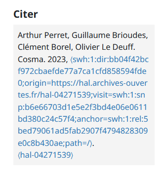

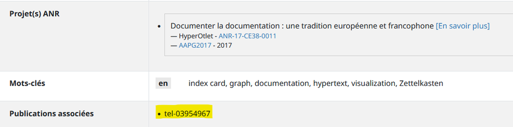

- [CV de chercheur/chercheuse](https://cv.hal.science/arthur-perret)
- page web de labo
- Rapports d’activité

# Place à la démo

[figure not shown]

📓 Louvet (2023)

# Crédits

Gif source code walking man sur [gifer](https://i.gifer.com/5TMy.gif)

# Références

Badolato, A.-M. (2024, June 3). *Highlights of the “Software Pillar of Open Science” workshop*. Ouvrir la Science. https://www.ouvrirlascience.fr/highlights-of-the-software-pillar-of-open-science-workshop

Louvet, V. (2023). Logiciels et codes sources, tour d’horizon. *Cellule Data Grenoble Alpes*. https://hal.science/hal-04173102/document

Perret, A., Brioudes, G., Borel, C., & Le Deuff, O. (2024). *Cosma* [Computer software]. https://github.com/graphlab-fr/cosma/ (Original work published 2021)

*Quarto-dev/quarto-cli: Open-source scientific and technical publishing system built on Pandoc.* (n.d.). [Computer software]. Retrieved June 9, 2024, from https://github.com/quarto-dev/quarto-cli